# Data Frame Summary

### Data Frame Summary

#### dd

**N**: 32

**No**

**Variable**

**Stats / Values**

**Freqs (% of Valid)**

**Graph**

**Valid**

**Missing**

1

mpg [numeric]

mean (sd) : 20.09 (6.03) min < med < max : 10.4 < 19.2 < 33.9 IQR (CV) : 7.38 (0.3)

25 distinct val.

32 (100%)

0 (0%)

2

cyl [numeric]

mean (sd) : 6.19 (1.79) min < med < max : 4 < 6 < 8 IQR (CV) : 4 (0.29)

4 : 11 (34.4%) 6 : 7 (21.9%) 8 : 14 (43.8%)

32 (100%)

0 (0%)

3

disp [numeric]

mean (sd) : 230.72 (123.94) min < med < max : 71.1 < 196.3 < 472 IQR (CV) : 205.18 (0.54)

27 distinct val.

32 (100%)

0 (0%)

4

hp [numeric]

mean (sd) : 146.69 (68.56) min < med < max : 52 < 123 < 335 IQR (CV) : 83.5 (0.47)

22 distinct val.

32 (100%)

0 (0%)

5

drat [character]

1. 3.07 2. 3.92 3. 2.76 4. 3.08 5. 3.15 6. 4.08 7. 4.22 8. Null 9. 2.93 10. 3 [ 12 others ]

3 ( 9.4%) 3 ( 9.4%) 2 ( 6.2%) 2 ( 6.2%) 2 ( 6.2%) 2 ( 6.2%) 2 ( 6.2%) 2 ( 6.2%) 1 ( 3.1%) 1 ( 3.1%) 12 (37.4%)

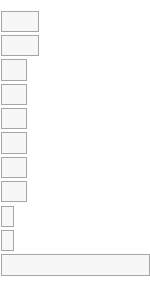

32 (100%)

0 (0%)

6

wt [character]

1. 3.44 2. 3.57 3. NA 4. 1.513 5. 1.615 6. 1.835 7. 1.935 8. 2.14 9. 2.2 10. 2.32 [ 18 others ]

3 ( 9.4%) 2 ( 6.2%) 2 ( 6.2%) 1 ( 3.1%) 1 ( 3.1%) 1 ( 3.1%) 1 ( 3.1%) 1 ( 3.1%) 1 ( 3.1%) 1 ( 3.1%) 18 (56.2%)

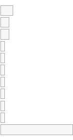

32 (100%)

0 (0%)

7

qsec [character]

1. . 2. 18.9 3. 14.5 4. 14.6 5. 15.41 6. 15.5 7. 15.84 8. 16.7 9. 16.87 10. 16.9 [ 17 others ]

5 (15.6%) 2 ( 6.2%) 1 ( 3.1%) 1 ( 3.1%) 1 ( 3.1%) 1 ( 3.1%) 1 ( 3.1%) 1 ( 3.1%) 1 ( 3.1%) 1 ( 3.1%) 17 (53.0%)

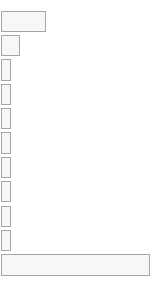

32 (100%)

0 (0%)

8

vs [numeric]

mean (sd) : 0.44 (0.5) min < med < max : 0 < 0 < 1 IQR (CV) : 1 (1.15)

2 distinct val.

32 (100%)

0 (0%)

9

am [numeric]

mean (sd) : 0.46 (0.51) min < med < max : 0 < 0 < 1 IQR (CV) : 1 (1.1)

2 distinct val.

26 (81.25%)

6 (18.75%)

10

gear [numeric]

mean (sd) : 3.69 (0.74) min < med < max : 3 < 4 < 5 IQR (CV) : 1 (0.2)

3 : 15 (46.9%) 4 : 12 (37.5%) 5 : 5 (15.6%)

32 (100%)

0 (0%)

11

carb [numeric]

mean (sd) : 2.81 (1.62) min < med < max : 1 < 2 < 8 IQR (CV) : 2 (0.57)

1 : 7 (21.9%) 2 : 10 (31.2%) 3 : 3 ( 9.4%) 4 : 10 (31.2%) 6 : 1 ( 3.1%) 8 : 1 ( 3.1%)

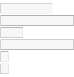

32 (100%)

0 (0%)

12

tt [character]

1. N 2. Y

18 (66.7%) 9 (33.3%)

27 (84.38%)

5 (15.62%)

13

bb [character]

1. A 2. B 3. C

19 (61.3%) 2 ( 6.4%) 10 (32.3%)

31 (96.88%)

1 (3.12%)

Generated by summarytools package version 0.8.2 ([R](https://www.r-project.org/) version 3.4.2)  
2018-03-03